**Logistic Regression**

|  | by Seungchul Lee iSystems Design Lab http://isystems.unist.ac.kr/ UNIST |
| --- | --- |

Table of Contents

# 1. Linear Classification: Logistic Regression

## 1.1. Using all Distances

- Logistic regression is a classification algorithm - don't be confused
- Perceptron: make use of sign of data
- SVM: make use of margin (minimum distance)
- We want to use *distance information of all data points* $\rightarrow$ logistic regression

[figure not shown]

- basic idea: find the decision boundary (hyperplane) of $g(x)=\omega^T x =0$ such that maximizes $\prod_i \lvert h_i \rvert$
  - Inequality of arithmetic and geometric means $$ \frac{h_1+h_2}{2} \geq \sqrt{h_1 h_2} $$ and that equality holds if and only if $h_1 = h_2$
- Roughly speaking, this optimization of $\max \prod_i \lvert h_i \rvert$ tends to position a hyperplane in the middle of two classes

$$h = \frac{g(x)}{\lVert \omega \rVert} = \frac{\omega^T x}{\lVert \omega \rVert} \approx \omega^T x$$

- We link or squeeze $(-\infty, +\infty)$ to $(0,1)$ for several reasons:

[figure not shown]

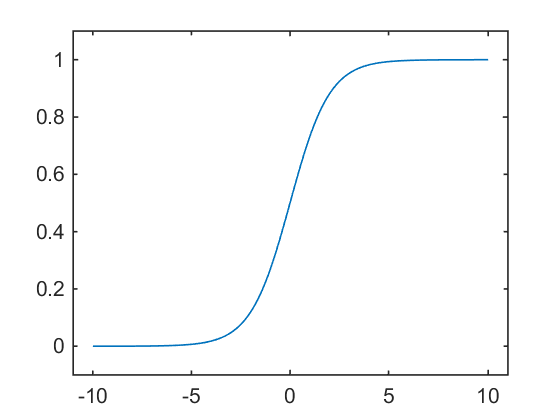

```matlab
% What does the sigmoid function look like

z = -10:0.1:10;
s = 1./(1+exp(-z));
plot(z,s)
xlim([-11,11]), ylim([-0.1 1.1])
```

- Benefit of mapping via the logistic function
  - monotonic: same or similar optimziation solution
  - continuous and differentiable: good for gradient descent optimization
  - probability or confidence: can be considered as probability

  $$P\left(y = +1 \mid x,\omega\right) = \frac{1}{1+e^{-\omega^T x}} \in [0,1]$$
  - Often we do note care about predicting the label $y$ for an example
  - Rather, we want to predict the label probabilities $P\left(y \mid x,\omega\right)$
    - $P\left(y = +1 \mid x,\omega\right)$: the probability that the label is $+1$
    - $P\left(y = 0 \mid x,\omega\right) = 1 - P\left(y = +1 \mid x,\omega\right)$: the probability that the label is $0$
    - In a sense, it is our confidence in the predicted label
- Goal: we need to fit $\omega$ to our data

## 1.2. Probabilistic Approach (or MLE)

Consider a random variable $ y \in \{0, 1\} $

$$P(y=+1) = p, \quad P(y=0) = 1-p$$

where $ p \in [0, 1]$, and is assumed to depend on a vector of explanatory variables $x \in \mathbb{R}^n$

the logistic model has the form

$$ \begin{align*} p &= \frac{1}{1+e^{-\omega^T x}} = \frac{e^{\omega^T x}}{e^{\omega^T x} + 1}\\ 1-p &= \frac{1}{e^{\omega^T x} + 1} \end{align*} $$

We can re-order the data so far $x_1, \cdots, x_q$, the outcome is $y = +1$, and for $x_{q+1}, \cdots, x_m$, the outcome is $y=0$

The likelihood function

$$\mathscr{L} = \prod\limits_{i=1}^{q}{p_i}\prod\limits_{i=q+1}^{m}{(1-p_i)} \qquad \left(\sim \prod_i \lvert h_i \rvert \right)$$

the log likelihood function

$$ \begin{align*} \mathscr{l}(\omega) &= \log \mathscr{L} = \sum\limits_{i=1}^{q}{\log p_i} + \sum\limits_{i=q+1}^{m}{\log(1 - p_i)} \\ & = \sum\limits_{i=1}^{q}{\log \frac{\exp\left(\omega^T x_i\right)}{1 + \exp \left(\omega^T x_i \right)}} + \sum\limits_{i=q+1}^{m}{\log \frac{1}{1+\exp \left(\omega^T x_i \right)}} \\ &= \sum\limits_{i=1}^{q}{\left(\omega^T x_i\right)} - \sum\limits_{i=1}^{m}{\log \left(1+\exp \left(\omega^T x_i \right) \right)} \end{align*} $$

Since $\mathscr{l}$ is a concave function of $\omega$, the logistic regression problem can be solved as a convex optimization problem

$$\hat{\omega} = \arg\max_{\omega} \mathscr{l}(\omega)$$

## 1.3. Example with CVX

$$ \begin{align*} \omega &= \begin{bmatrix} \omega_1 \\ \omega_2 \\ \omega_3\end{bmatrix}, \quad x = \begin{bmatrix} x_1 \\ x_2 \\ 1\end{bmatrix}\\ X &= \begin{bmatrix} \left(x^{(1)}\right)^T \\ \left(x^{(2)}\right)^T \\ \left(x^{(3)}\right)^T \\ \vdots\end{bmatrix} = \begin{bmatrix} x_1^{(1)} & x_2^{(1)} & 1 \\x_1^{(2)} & x_2^{(2)} & 1 \\x_1^{(3)} & x_2^{(3)} & 1 \\ \vdots & \vdots & \vdots \\\end{bmatrix} \end{align*} $$

Source: Section 7.1.1 from http://cvxr.com/cvx/examples/cvxbook/Ch07_statistical_estim/html/logistics.html

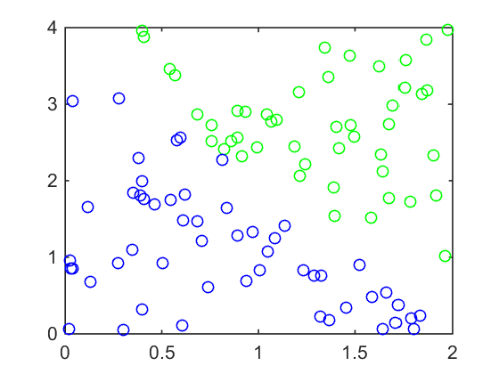

```matlab
%plot -s 560,420

% Boyd & Vandenberghe, "Convex Optimization"
% Original by Lieven Vandenberghe
% Adapted for CVX by Argyris Zymnis - 01/31/06

% Generate data

rand('state',0);

m = 100;
w = [2;1;-4];

X = [2*rand(m,1) 4*rand(m,1) ones(m,1)];

y = 0.5 < exp(X*w)./(1+exp(X*w));

c1 = find(y == 1);
c2 = find(y == 0);

plot(X(c1,1),X(c1,2),'go',X(c2,1),X(c2,2),'bo');
```

$$ \begin{align*} \mathscr{l}(\omega) &= \log \mathscr{L} = \sum\limits_{i=1}^{q}{\log p_i} + \sum\limits_{i=q+1}^{m}{\log(1 - p_i)} \\ & = \sum\limits_{i=1}^{q}{\log \frac{\exp\left(\omega^T x_i\right)}{1 + \exp \left(\omega^T x_i \right)}} + \sum\limits_{i=q+1}^{m}{\log \frac{1}{1+\exp \left(\omega^T x_i \right)}} \\ &= \sum\limits_{i=1}^{q}{\left(\omega^T x_i\right)} - \sum\limits_{i=1}^{m}{\log \left(1+\exp \left(\omega^T x_i \right) \right)} \end{align*} $$

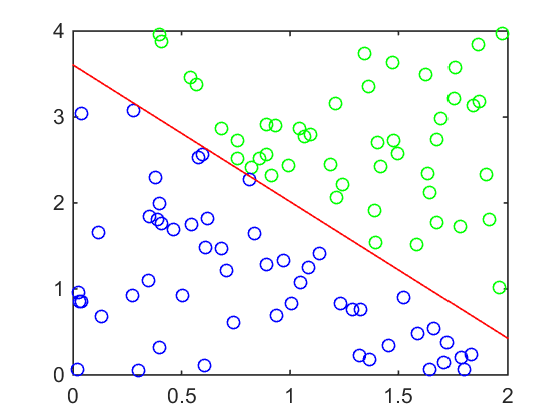

[output not shown]

```matlab
clear w

cvx_begin quiet
    variable w(3,1)
    maximize(y'*X*w - sum(log_sum_exp([zeros(1,m); w'*X'])))
cvx_end

xp = 0:0.1:2;
yp = (-w(3) - w(1)*xp)./w(2);

plot(X(c1,1),X(c1,2),'go',X(c2,1),X(c2,2),'bo'),    hold on
plot(xp,yp,'r'),    hold off
```

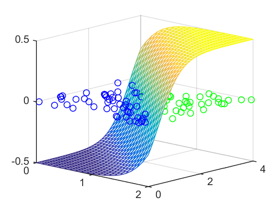

```matlab
[X1,X2] = meshgrid(0:0.1:2,0:0.1:4);

w = w/norm(w,2)*10; % coefficients adjustment
Z = exp(X1*w(1) + X2*w(2) + w(3))./(1 + exp(X1*w(1) + X2*w(2) + w(3)))-1/2; % plane shifted down to 1/2

plot3(X(c1,1),X(c1,2),zeros(length(c1),1),'go',X(c2,1),X(c2,2),zeros(length(c2),1),'bo'), hold on
mesh(X1,X2,Z), hold off
grid on, view(43,16)
```

```matlab
help log_sum_exp
```

```
LOG_SUM_EXP    log(sum(exp(x))).
    LOG_SUM_EXP(X) = LOG(SUM(EXP(X)).

    When used in a CVX model, LOG_SUM_EXP(X) causes CVX's successive
    approximation method to be invoked, producing results exact to within
    the tolerance of the solver. This is in contrast to LOGSUMEXP_SDP,
    which uses a single SDP-representable global approximation.

    If X is a matrix, LOGSUMEXP_SDP(X) will perform its computations
    along each column of X. If X is an N-D array, LOGSUMEXP_SDP(X)
    will perform its computations along the first dimension of size
    other than 1. LOGSUMEXP_SDP(X,DIM) will perform its computations
    along dimension DIM.

    Disciplined convex programming information:
        LOG_SUM_EXP(X) is convex and nondecreasing in X; therefore, X
        must be convex (or affine).

    Overloaded methods:
       cvx/log_sum_exp
```

**In a more compact form**

Change $y \in \{0,+1\} \rightarrow y \in \{-1,+1\}$ for compuational convenience

- Consider the following function

$$P\left(y \mid x,\omega\right) = \sigma\left(y\omega^Tx\right) = \frac{1}{1+\exp\left(-y\omega^T x\right)} \in [0,1]$$

- Log-likelihood

$$ \begin{align*} \mathscr{l}(\omega) = \log \mathscr{L} = \log P\left(y \mid x,\omega\right)& = \log \prod_{n=1}^{m} P\left(y_n \mid x_n,\omega\right)\\ &= \sum_{n=1}^{m} \log P\left(y_n \mid x_n,\omega\right)\\ &= \sum_{n=1}^{m} \log \frac{1}{1+\exp\left(-y_n\omega^T x_n\right)}\\ &= \sum\limits_{n=1}^{m}{-\log \left(1+\exp \left(-y_n\omega^T x_n \right) \right)} \end{align*} $$

- MLE solution

$$ \begin{align*} \hat{\omega} &= \arg \max_{\omega} \sum\limits_{n=1}^{m}{-\log \left(1+\exp \left(-y_n\omega^T x_n \right) \right)}\\ &= \arg \min_{\omega} \sum\limits_{n=1}^{m}{\log \left(1+\exp \left(-y_n\omega^T x_n \right) \right)} \end{align*} $$

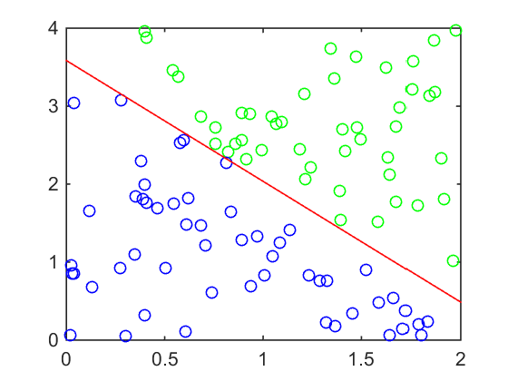

```matlab
%%
y = double(y);
y(y == 0) = -1;

clear w

cvx_begin quiet
    variable w(3,1)
    minimize (sum(log_sum_exp([zeros(1,m); (y.*(X*w))'])))
cvx_end

xp = 0:0.1:2;
yp = (-w(3) - w(1)*xp)./w(2);

plot(X(c1,1),X(c1,2),'go',X(c2,1),X(c2,2),'bo'),    hold on
plot(xp,yp,'r'),    hold off
```

## 1.4. Logistic Regression with Gradient Descent (Optional)

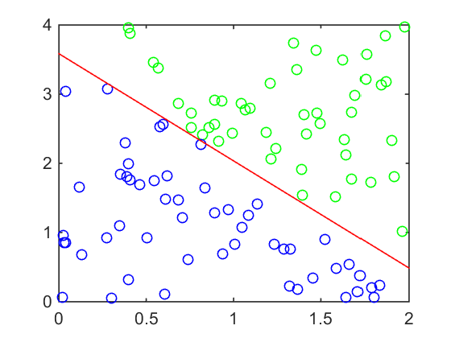

```matlab
%% logistic regression using gradient descent

y = double(y);
y(y == 0) = -1;

k = size(X,2);
theta = zeros(k,1);

g = 1;

while (norm(g) > 1e-10)
    z = 1./(1 + exp(y.*(X*theta)));
    g = -X'*(z.*y);
    H = X'*diag(z.*(1-z))*X;
    theta = theta - H\g;
end

%% plot
xp = 0:0.1:2;
yp = (-w(3) - w(1)*xp)./w(2);

plot(X(c1,1),X(c1,2),'go',X(c2,1),X(c2,2),'bo'),    hold on
plot(xp,yp,'r'),    hold off
```

# 2. Regularized Logistic Regression

- $l_2$ regularized logistic regression
  - make $\omega$ small $$ \begin{align*} \min_{\omega} &\; \lambda \rVert \omega \lVert_2^2 + \sum\limits_{n=1}^{m}{\log \left(1+\exp \left(-y_n\omega^T x_n \right) \right)} \end{align*} $$
- $l_1$ regularized logistic regression
  - make $\omega$ small and sparse $\rightarrow$ feature selection for classification

$$ \begin{align*} \min_{\omega} &\; \lambda \rVert \omega \lVert_1 + \sum\limits_{n=1}^{m}{\log \left(1+\exp \left(-y_n\omega^T x_n \right) \right)} \end{align*} $$

- The effect of regularization will be more clearly illustrated with a non-linear data set

```matlab
%plot -s 560,420

% Generate data
rand('state',0);

m = 100;
w = [2;1;-4];

X = [2*rand(m,1) 4*rand(m,1) ones(m,1)];

y = 0.5 < exp(X*w)./(1+exp(X*w));

c1 = find(y == 1);
c2 = find(y == 0);

y = double(y);
y(y == 0) = -1;
```

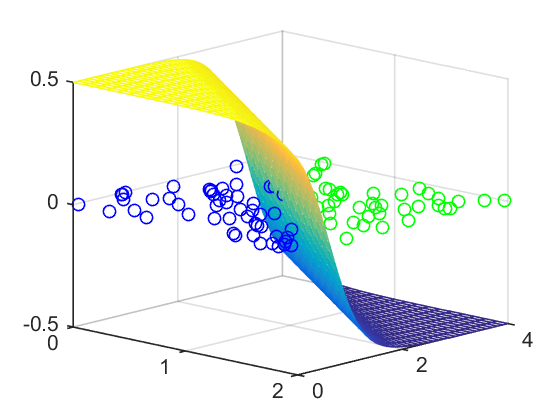

```matlab
%%
clear w
g = 1;

cvx_begin quiet
    variable w(3,1)
    minimize (g*norm(w,2) + sum(log_sum_exp([zeros(1,m); (y.*(X*w))'])))
cvx_end

[X1,X2] = meshgrid(0:0.1:2,0:0.1:4);

Z = exp(X1*w(1) + X2*w(2) + w(3))./(1 + exp(X1*w(1) + X2*w(2) + w(3)))-1/2; % plane shifted down to 1/2

plot3(X(c1,1),X(c1,2),zeros(length(c1),1),'go',X(c2,1),X(c2,2),zeros(length(c2),1),'bo'), hold on
mesh(X1,X2,Z), hold off
grid on, view(43,16)
```

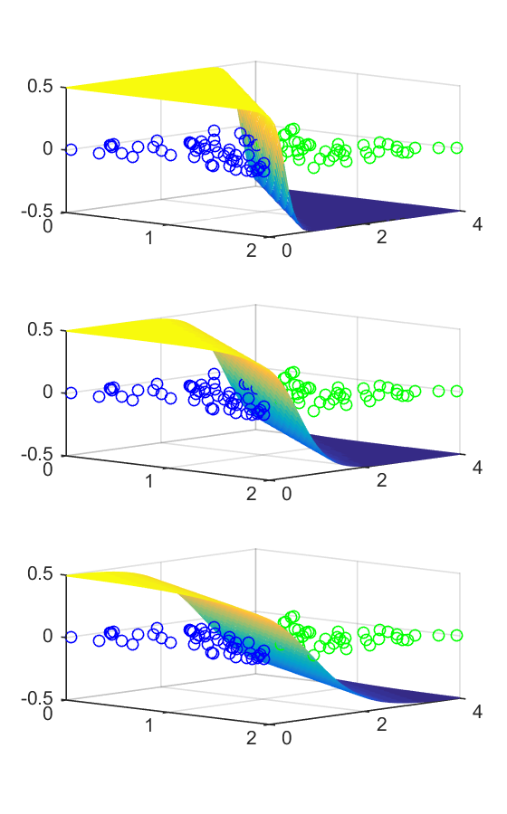

```matlab
%plot -s 560,900

clear w
g = [0.1 1 3];

for i = 1:3
    cvx_begin quiet
        variable w(3,1)
        minimize (g(i)*norm(w,2) + sum(log_sum_exp([zeros(1,m); (y.*(X*w))'])))
    cvx_end

    [X1,X2] = meshgrid(0:0.1:2,0:0.1:4);

    Z = exp(X1*w(1) + X2*w(2) + w(3))./(1 + exp(X1*w(1) + X2*w(2) + w(3)))-1/2; % plane shifted down to 1/2

    subplot(3,1,i),  plot3(X(c1,1),X(c1,2),zeros(length(c1),1),'go',X(c2,1),X(c2,2),zeros(length(c2),1),'bo'), hold on
    mesh(X1,X2,Z), hold off
    grid on, view(43,16)
end
```

- $l_1$ regularized logistic regression
  - make $\omega$ small and sparse $\rightarrow$ feature selection for classification

$$ \begin{align*} \min_{\omega} &\; \lambda \rVert \omega \lVert_1 + \sum\limits_{n=1}^{m}{\log \left(1+\exp \left(-y_n\omega^T x_n \right) \right)} \end{align*} $$

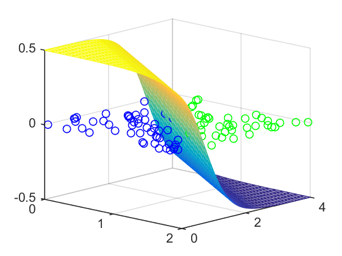

```matlab
%plot -s 560,420

clear w
g = 1;

cvx_begin quiet
    variable w(3,1)
    minimize (g*norm(w,1) + sum(log_sum_exp([zeros(1,m); (y.*(X*w))'])))
cvx_end

[X1,X2] = meshgrid(0:0.1:2,0:0.1:4);

Z = exp(X1*w(1) + X2*w(2) + w(3))./(1 + exp(X1*w(1) + X2*w(2) + w(3)))-1/2; % plane shifted down to 1/2

plot3(X(c1,1),X(c1,2),zeros(length(c1),1),'go',X(c2,1),X(c2,2),zeros(length(c2),1),'bo'), hold on
mesh(X1,X2,Z), hold off
grid on, view(43,16)
```

# 3. Multiclass Classification (Optional)

- Generalization to more than 2 classes is straightforward
- Using the soft-max function instead of the logistic function

$$P\left(y = k \mid x,\omega\right) = \frac{\exp{\left( \omega_k^T x \right) }}{\sum_k \exp{\left(\omega_k^T x \right)}} \in [0,1]$$

- We maintain a separator weight vector $\omega_k$ for each class $k$

# 4. Non-linear Classification (Optional)

- Same idea as for linear regression: non-linear features, either explicit or implicit Kernels

## 4.1. Explicit Feature Vector

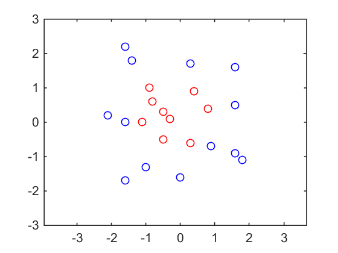

```matlab
x_c1 = [-1.1  0;
        -0.3  0.1;
        -0.9  1;
         0.8  0.4;
         0.4  0.9;
         0.3 -0.6;
        -0.5  0.3;
        -0.8  0.6
        -0.5 -0.5];

x_c2 = [-1   -1.3;
        -1.6  2.2;
         0.9 -0.7;
         1.6  0.5;
         1.8 -1.1;
         1.6  1.6;
        -1.6 -1.7;
        -1.4  1.8;
         1.6 -0.9;
         0   -1.6;
         0.3  1.7;
        -1.6  0;
        -2.1  0.2;];

plot(x_c1(:,1),x_c1(:,2),'ro',x_c2(:,1),x_c2(:,2),'bo')
axis([-3 3 -3 3]), axis equal
```

$$ x = \begin{bmatrix} x_1 \\ x_2 \end{bmatrix} \quad \Longrightarrow \quad z = \phi(x) = \begin{bmatrix} 1\\ \sqrt{2}x_1\\ \sqrt{2}x_2 \\x_1^2 \\ \sqrt{2}x_1 x_2 \\x_2^2 \end{bmatrix} $$

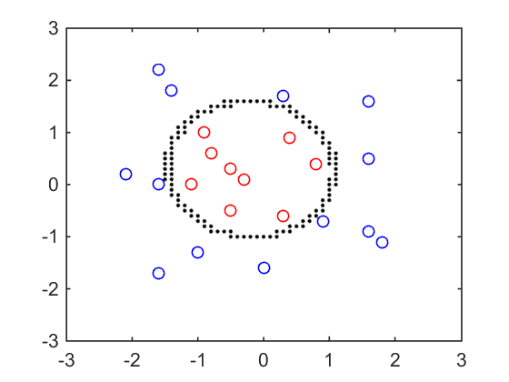

```matlab
%% estimate w from logistic regression
X = [x_c1; x_c2];
y = [ones(length(x_c1),1); -ones(length(x_c2),1)];

m = length(y);

% nonlinear feature mapping
Z = [ones(m,1), sqrt(2)*X(:,1), sqrt(2)*X(:,2), ...
    X(:,1).^2, sqrt(2)*X(:,1).*X(:,2), X(:,2).^2];

clear w
cvx_begin quiet
    variable w(6,1)
    minimize (sum(log_sum_exp([zeros(1,m); (y.*(Z*w))'])))
cvx_end

w = w/norm(w)*10; % normalize

%% evaluate grid data for finding decision boundary
[X1g, X2g] = meshgrid(-3:0.1:3,-3:0.1:3);
X_test = [X1g(:) X2g(:)];

m = length(X_test);

Z_test = [ones(m,1), sqrt(2)*X_test(:,1), sqrt(2)*X_test(:,2), ...
          X_test(:,1).^2, sqrt(2)*X_test(:,1).*X_test(:,2), X_test(:,2).^2];

y_hat = 1./(1 + exp(-Z_test*w));

% plotting a decision boundary
B = [];
for i = 1:length(y_hat)
    if abs(y_hat(i)-0.5) < 0.2
        B = [B; X_test(i,:)];
    end
end

plot(x_c1(:,1),x_c1(:,2),'ro',x_c2(:,1),x_c2(:,2),'bo'), hold on
plot(B(:,1),B(:,2),'k.'),   hold off
axis([-3 3 -3 3])
```

- $l_2$ regularized logistic regression
  - non-linear and overfitting
  - make $\omega$ small $$ \begin{align*} \min_{\omega} &\; \lambda \rVert \omega \lVert_2^2 + \sum\limits_{n=1}^{m}{\log \left(1+\exp \left(-y_n\omega^T x_n \right) \right)} \end{align*} $$

Download the data files

- [download nonlinear x](https://www.dropbox.com/s/bsxxcahjm31gv9s/nonlinear_x.dat?dl=0)
- [download nonlinear y](https://www.dropbox.com/s/6939y9e8jm9xp55/nonlinear_y.dat?dl=0)

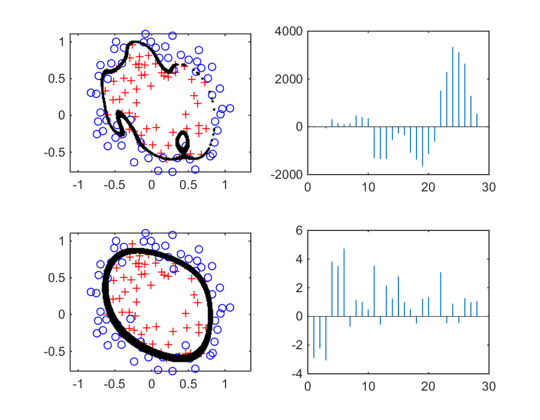

```matlab
%plot -s 900,700
% source: By Andrew Ng at Stanford Univ.
% http://openclassroom.stanford.edu/MainFolder/DocumentPage.php?course=MachineLearning&doc=exercises/ex5/ex5.html

X = load([pwd,'\image_files\nonlinear_x.dat']);
y = load([pwd,'\image_files\nonlinear_y.dat']);

y(y == 0) = -1;

pos = find(y+1);
neg = find(y-1);
plot(X(pos,1),X(pos,2),'r+',X(neg,1),X(neg,2),'bo')
axis equal

%% estimate w from regularized logistic regression for non-linear data
m = length(y);
d = 6;

% polynomial functions
Z = ones(m,1);
for i = 1:d
    for j = 0:i
        Z = [Z (X(:,1).^(i-j)).*(X(:,2).^j)];
    end
end

n = size(Z,2);

[X1g, X2g] = meshgrid(-3:0.01:3,-3:0.01:3);
X_test = [X1g(:) X2g(:)];

Z_test = ones(length(X_test),1);

for i = 1:d
    for j = 0:i
        Z_test = [Z_test (X_test(:,1).^(i-j)).*(X_test(:,2).^j)];
    end
end

g = [0 1];

for k = 1:length(g)
    clear w
    cvx_begin quiet
        variable w(n,1)
        minimize (g(k)*norm(w,2) + sum(log_sum_exp([zeros(1,m); (y.*(Z*w))'])))
    cvx_end

    y_hat = 1./(1 + exp(-Z_test*w));

    % plotting a decision boundary
    B = [];
    for i = 1:length(y_hat)
        if abs(y_hat(i)-0.5) < 0.1
            B = [B; X_test(i,:)];
        end
    end

    subplot(length(g),2,2*k-1), plot(X(pos,1),X(pos,2),'r+',X(neg,1),X(neg,2),'bo'), hold on
    plot(B(:,1),B(:,2),'k.'),   hold off, axis equal
    subplot(length(g),2,2*k), stem(w,'marker','none')
end
```

- $l_1$ regularized logistic regression
  - nonlinear, overfitting, and too many features
  - make $\omega$ small and sparse $\rightarrow$ feature selection for classification

$$ \begin{align*} \min_{\omega} &\; \lambda \rVert \omega \lVert_1 + \sum\limits_{n=1}^{m}{\log \left(1+\exp \left(-y_n\omega^T x_n \right) \right)} \end{align*} $$

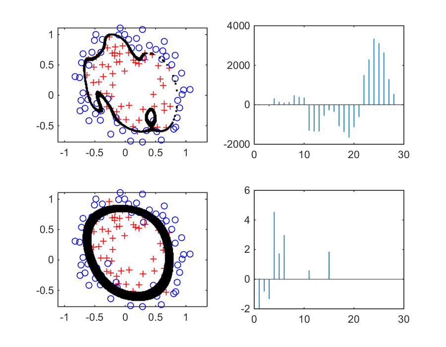

```matlab
%plot -s 900,700
X = load([pwd,'\image_files\nonlinear_x.dat']);
y = load([pwd,'\image_files\nonlinear_y.dat']);

y(y == 0) = -1;

pos = find(y+1);
neg = find(y-1);
plot(X(pos,1),X(pos,2),'r+',X(neg,1),X(neg,2),'bo')
axis equal

%% estimate w from regularized logistic regression for non-linear data
m = length(y);
d = 6;

% polynomial functions
Z = ones(m,1);
for i = 1:d
    for j = 0:i
        Z = [Z (X(:,1).^(i-j)).*(X(:,2).^j)];
    end
end

n = size(Z,2);

[X1g, X2g] = meshgrid(-3:0.01:3,-3:0.01:3);
X_test = [X1g(:) X2g(:)];

Z_test = ones(length(X_test),1);

for i = 1:d
    for j = 0:i
        Z_test = [Z_test (X_test(:,1).^(i-j)).*(X_test(:,2).^j)];
    end
end

g = [0 1];

for k = 1:length(g)
    clear w
    cvx_begin quiet
        variable w(n,1)
        minimize (g(k)*norm(w,1) + sum(log_sum_exp([zeros(1,m); (y.*(Z*w))'])))
    cvx_end

    y_hat = 1./(1 + exp(-Z_test*w));

    % plotting a decision boundary
    B = [];
    for i = 1:length(y_hat)
        if abs(y_hat(i)-0.5) < 0.1
            B = [B; X_test(i,:)];
        end
    end

    subplot(length(g),2,2*k-1), plot(X(pos,1),X(pos,2),'r+',X(neg,1),X(neg,2),'bo'), hold on
    plot(B(:,1),B(:,2),'k.'),   hold off, axis equal
    subplot(length(g),2,2*k), stem(w,'marker','none')
end
```

## 4.2. Implicit Feature Vector (Kernel)

```matlab
%%javascript
$.getScript('https://kmahelona.github.io/ipython_notebook_goodies/ipython_notebook_toc.js')
```